# Classification

# Classification Intro

# width and length

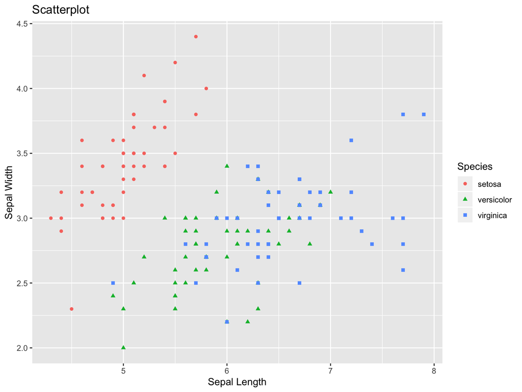

```r
 ggplot(data=iris, aes(x=Sepal.Length, y=Sepal.Width, color=Species)) +
  geom_point(aes(shape=Species), size=1.5) + xlab("Sepal Length") + ylab("Sepal Width") +
  ggtitle("Scatterplot ")
```

# Classification Intro

- data:

  +$(x_i,y_i)$, $x_i=(x_{i1},\cdots, x_{ip})$

  +$y_i$ is categorical, can take values $\mathcal{C}_k, k=1, ..., K$
  - classification: given x, determine $\hat{y}$
- Model
  - Objects are divided into K categories $\mathcal{C}_k, k=1, ..., K$
  - Prior probability $P(y=\mathcal{C}_k)$
  - Conditional probability $P(x|y=\mathcal{C}_k)$
  - Decision region: $\hat{y}=\mathcal{R}(x)=1,\cdots, K$
- Accuracy
  - training error rate:

  $$\frac{1}{n}\sum_{i=1}^{n}(I(y_i\ne \hat{y}_i))$$
  - testing error rate

  $$E(I(Y \ne \hat{Y}))$$

# Classification Intro

- Bayesian decision bounary
  - the posterior probability
    $$P(\mathcal{C}_k|x)=\frac{P(x|\mathcal{C}_k)P(\mathcal{C}_k)}{P(x)}$$
  - Bayesian decision: $\mathcal{R}(x)=k$ if $P(\mathcal{C}_k|x) > P(\mathcal{C}_j|x)$ for $j\ne k$
  - Bayesian decision: assign an object to class $\mathcal{C}_k$ for which the posterior probability $P(\mathcal{C}_k|x)$ is largest.
  - Bayesian error rate:
    $$1- E(\max_k P(\mathcal{C}_k|X))$$
  - Theorem: Bayesian classifier has the lowest possible test error rate

# Logistic Regression

- data: $(x_i,y_i)$, $x_i=(x_{i1},\cdots, x_{ip})$
- $y_i$ is categorical
- Assumption: $Y$ follows a Bernoulli distribution $Pr(y_i=1|x_i)=p_i$ is a function of $x_i=(x_{i1},\cdots, x_{ip})$.
- a Bernoulli rv $Y_i$ has probability mass function $f(y_i)=P(Y_i=y_i)=p_i^{y_i} (1-p_i)^{1-y_i}$, where $y_i=0,1$.
- We could assume that $p_i$ to be an unknown function of $x_i$
  - For example, one can try $p_i=\beta_0 +\beta_1 x_{i1}+\cdots+\beta_1 x_{ip}=x_i^T \beta$
  - However, this linear function has its problem

# Logistic Regression

- Logistic Model:
  $$p_i=E(y_i)=\frac{\exp (x_i^T \beta)}{1+\exp (x_i^T \beta)}$$
- log odds (logit)
  $$log\left(\frac{p_i}{1-p_i}\right)=x_i^T \beta$$
- Keeping everything else the same, one unit increase in $x_{j}$ results in $\beta_j$ unit change in log odds. Equivalently, it multiplies the odds by $e^{\hat{\beta}_j}$.
- the amount that $p_i$ changes due to one unit change of a predictor depends on the current value of the predictor.

# shape of logistic function

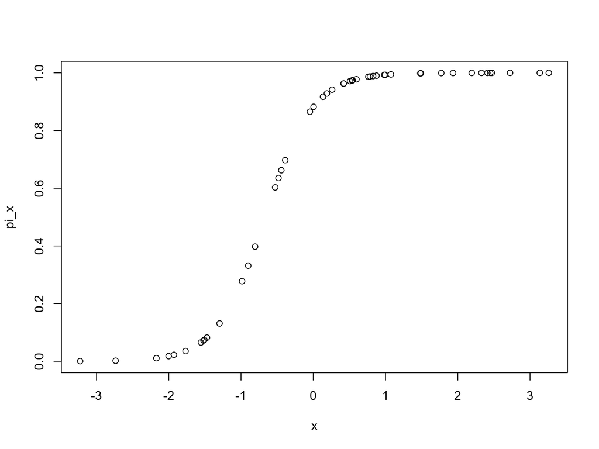

```r
n=50;
x<-rnorm(n,0,2);
pi_x<-exp(2+3*x)/(1+exp(2+3*x))
plot(x,pi_x)
```

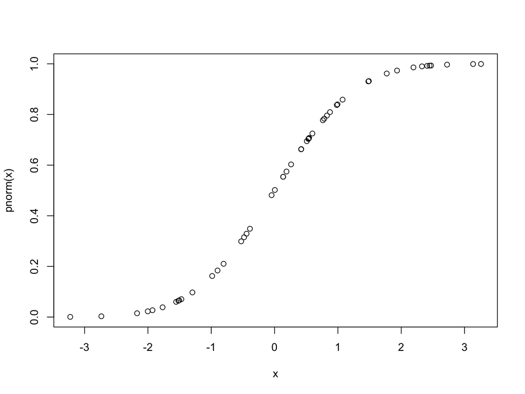

```r
plot(x,pnorm(x))
```

# Logistic Regression

- Logistic Model:
  $$p_i=E(y_i)=\frac{\exp (x_i^T \beta)}{1+\exp (x_i^T \beta)}$$
- The likelihood function is
  $$L(\beta, y_i,\ldots, y_n)=\prod_{i=1}^{n} p_i^{y_i} (1-p_i)^{1-y_i}$$
- by maximizing the likelihood function we may numerically find the estimates of $\beta$, $\hat{\beta}$.

# Logistic Regression

- Examples: iris data
- change the response variable into two categories

```r
library(ggplot2)
head(iris)
```

```
##   Sepal.Length Sepal.Width Petal.Length Petal.Width Species
## 1          5.1         3.5          1.4         0.2  setosa
## 2          4.9         3.0          1.4         0.2  setosa
## 3          4.7         3.2          1.3         0.2  setosa
## 4          4.6         3.1          1.5         0.2  setosa
## 5          5.0         3.6          1.4         0.2  setosa
## 6          5.4         3.9          1.7         0.4  setosa
```

```r
my.iris<-iris
# select y to be setosa

my.iris$y<-iris$Species=="setosa"
my.iris$y<-as.factor(my.iris$y)
levels(my.iris$y)<-c("others", "Setosa")
my.iris$Species<-NULL
head(my.iris)
```

```
##   Sepal.Length Sepal.Width Petal.Length Petal.Width      y
## 1          5.1         3.5          1.4         0.2 Setosa
## 2          4.9         3.0          1.4         0.2 Setosa
## 3          4.7         3.2          1.3         0.2 Setosa
## 4          4.6         3.1          1.5         0.2 Setosa
## 5          5.0         3.6          1.4         0.2 Setosa
## 6          5.4         3.9          1.7         0.4 Setosa
```

# Logistic Regression

```r
#my.iris<-iris[iris$Species!="virginica",]
#droplevels(my.iris)
glmfit1<- glm(y~ Sepal.Width, data=my.iris, family = binomial)
summary(glmfit1)
```

```
##
## Call:
## glm(formula = y ~ Sepal.Width, family = binomial, data = my.iris)
##
## Deviance Residuals:
##     Min       1Q   Median       3Q      Max
## -2.2636  -0.6790  -0.3458   0.5032   3.0698
##
## Coefficients:
##             Estimate Std. Error z value Pr(>|z|)
## (Intercept) -15.7189     2.6217  -5.996 2.03e-09 ***
## Sepal.Width   4.7896     0.8246   5.809 6.29e-09 ***
## ---
## Signif. codes:  0 '***' 0.001 '**' 0.01 '*' 0.05 '.' 0.1 ' ' 1
##
## (Dispersion parameter for binomial family taken to be 1)
##
##     Null deviance: 190.95  on 149  degrees of freedom
## Residual deviance: 123.83  on 148  degrees of freedom
## AIC: 127.83
##
## Number of Fisher Scoring iterations: 5
```

```r
prob.predict<-predict(glmfit1, type="response")
c.predict<-rep("other", length(my.iris$y))
c.predict[prob.predict>0.5]<-"setosa"
t1<-table("original"=my.iris$y, "predicted"=c.predict)
t1
```

```
##         predicted
## original other setosa
##   others    90     10
##   Setosa    17     33
```

```r
p.t1<-prop.table(t1,1)

t1.mar<-addmargins(t1)
(t1.mar)
```

```
##         predicted
## original other setosa Sum
##   others    90     10 100
##   Setosa    17     33  50
##   Sum      107     43 150
```

```r
library(knitr)


kable(as.data.frame(t1))
```

| original | predicted | Freq |
| --- | --- | --- |
| others | other | 90 |
| Setosa | other | 17 |
| others | setosa | 10 |
| Setosa | setosa | 33 |

# Logistic Regression

- four predictors

```r
glmfit2<- glm(y~., data=my.iris, family = binomial)
summary(glmfit2)
```

```
##
## Call:
## glm(formula = y ~ ., family = binomial, data = my.iris)
##
## Deviance Residuals:
##        Min          1Q      Median          3Q         Max
## -3.185e-05  -2.100e-08  -2.100e-08   2.100e-08   3.173e-05
##
## Coefficients:
##                Estimate Std. Error z value Pr(>|z|)
## (Intercept)     -16.946 457457.097       0        1
## Sepal.Length     11.759 130504.042       0        1
## Sepal.Width       7.842  59415.385       0        1
## Petal.Length    -20.088 107724.594       0        1
## Petal.Width     -21.608 154350.616       0        1
##
## (Dispersion parameter for binomial family taken to be 1)
##
##     Null deviance: 1.9095e+02  on 149  degrees of freedom
## Residual deviance: 3.2940e-09  on 145  degrees of freedom
## AIC: 10
##
## Number of Fisher Scoring iterations: 25
```

```r
prob.predict2<-predict(glmfit2, type="response")
c.predict2<-rep("other", length(my.iris$y))
c.predict2[prob.predict2>0.5]<-"setosa"
t2<-table(my.iris$y, c.predict2)
t2
```

```
##         c.predict2
##          other setosa
##   others   100      0
##   Setosa     0     50
```

# Default example

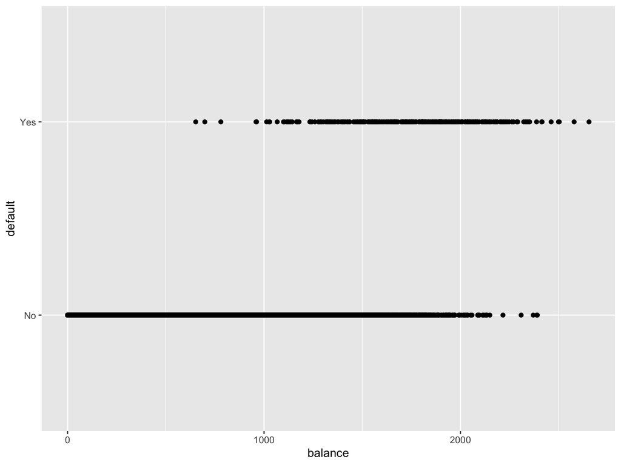

```r
library(ggplot2)
require(ISLR)
#View(Default)
attach(Default)
qplot(balance, default)
```

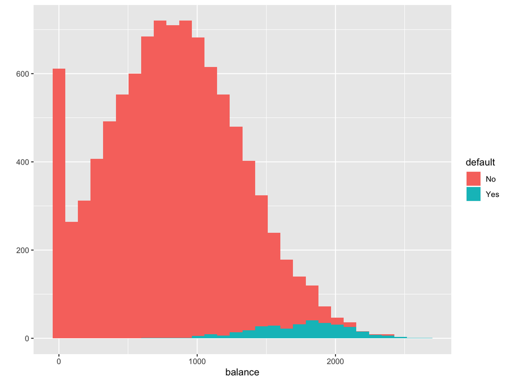

```r
qplot(balance, fill=default)
```

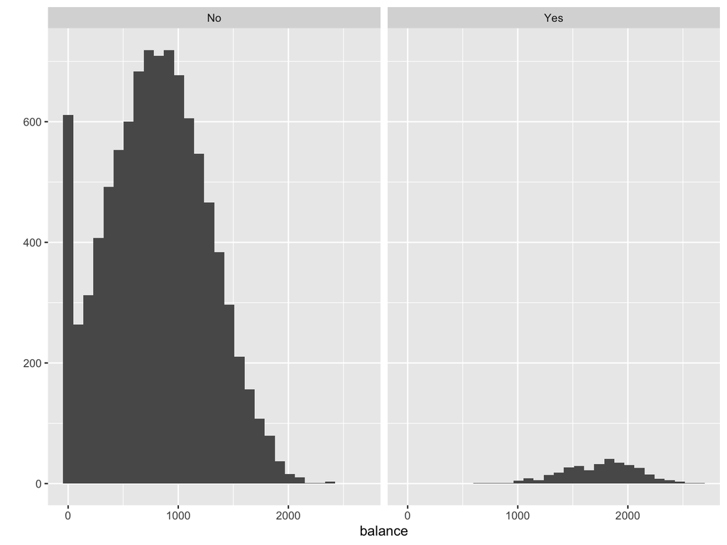

```r
qplot(balance,data=Default, facets =.~ default)
```

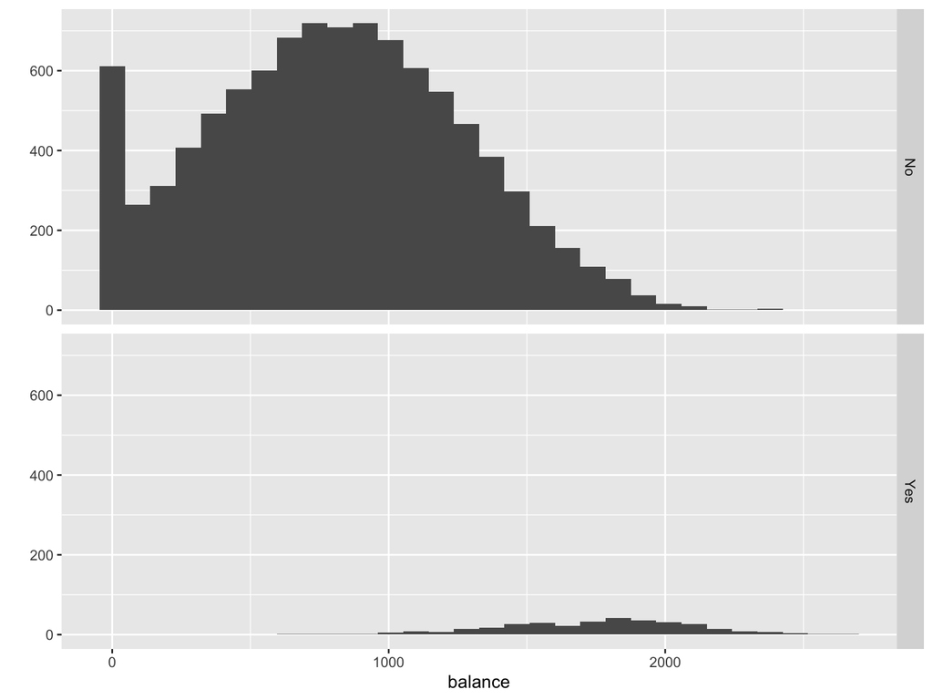

```r
qplot(balance,data=Default, facets =default~.)
```

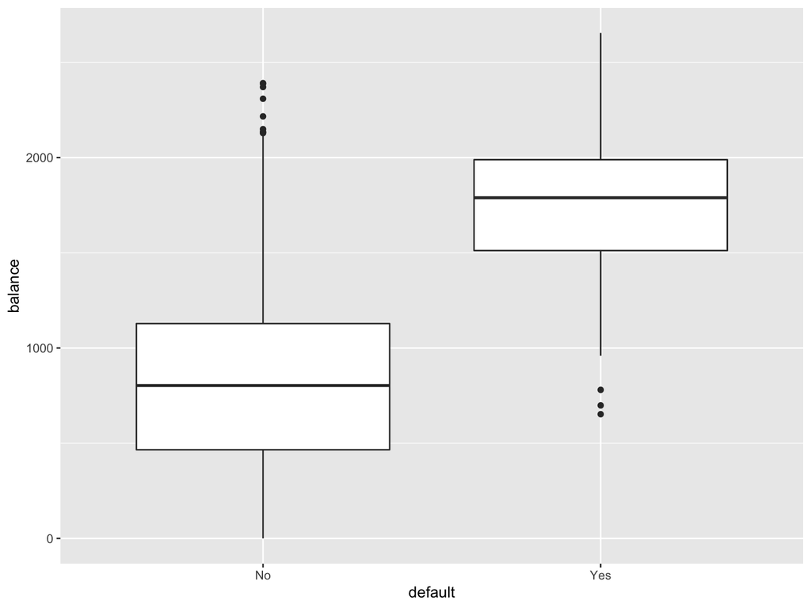

```r
qplot(default, balance, geom ="boxplot")
```

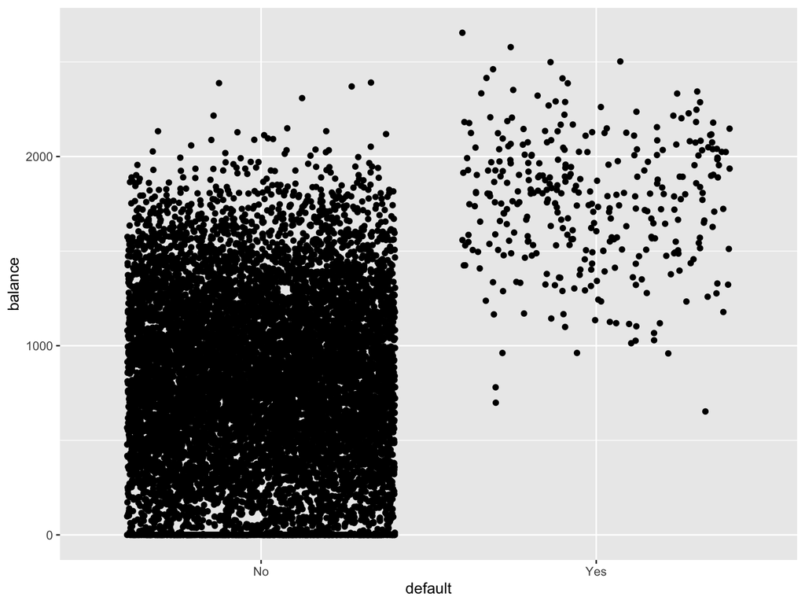

```r
qplot(default, balance, geom ="jitter")
```

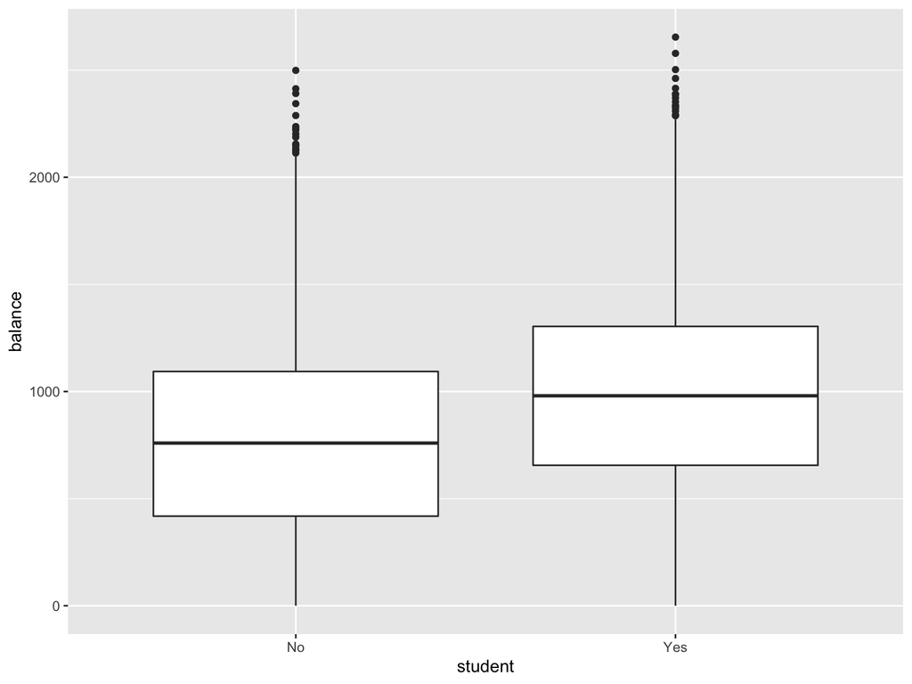

```r
qplot(student, balance, geom ="boxplot")
```

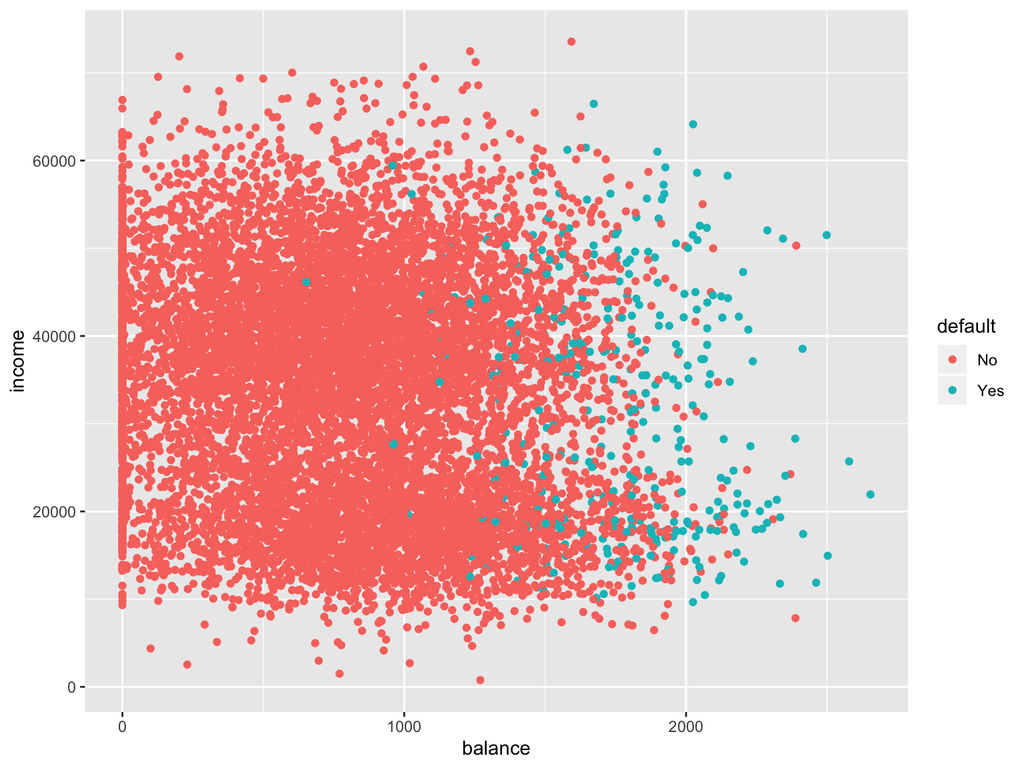

```r
qplot(balance, income, color= default)
```

```r
detach(Default)
```

# Default example

```r
Default<-na.omit(Default)
c_fit1<-glm(default~balance, data=Default, family = binomial)
summary(c_fit1)
```

```
##
## Call:
## glm(formula = default ~ balance, family = binomial, data = Default)
##
## Deviance Residuals:
##     Min       1Q   Median       3Q      Max
## -2.2697  -0.1465  -0.0589  -0.0221   3.7589
##
## Coefficients:
##               Estimate Std. Error z value Pr(>|z|)
## (Intercept) -1.065e+01  3.612e-01  -29.49   <2e-16 ***
## balance      5.499e-03  2.204e-04   24.95   <2e-16 ***
## ---
## Signif. codes:  0 '***' 0.001 '**' 0.01 '*' 0.05 '.' 0.1 ' ' 1
##
## (Dispersion parameter for binomial family taken to be 1)
##
##     Null deviance: 2920.6  on 9999  degrees of freedom
## Residual deviance: 1596.5  on 9998  degrees of freedom
## AIC: 1600.5
##
## Number of Fisher Scoring iterations: 8
```

```r
coef(c_fit1)
```

```
##   (Intercept)       balance
## -10.651330614   0.005498917
```

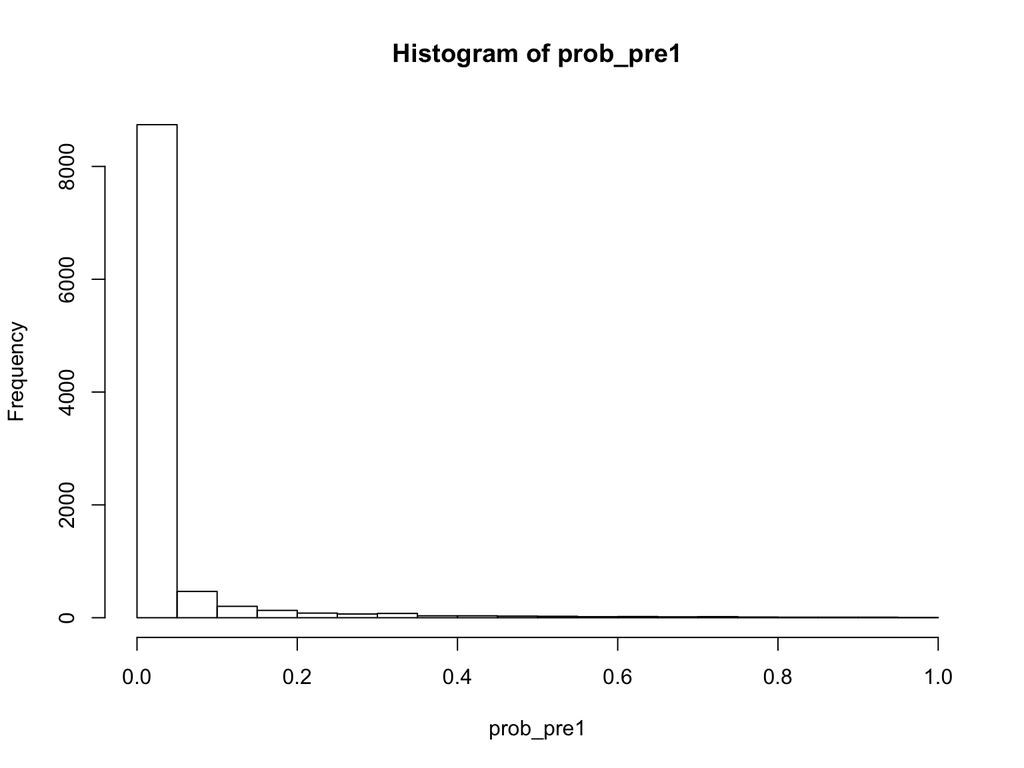

```r
prob_pre1<-predict(c_fit1, type="response")
hist(prob_pre1)
```

```r
default.predict<-rep("No", length(Default$default))
default.predict[prob_pre1>0.5]<-"Yes"
t1<-table("original"=Default$defaul, "predicted"=default.predict)
t1
```

```
##         predicted
## original   No  Yes
##      No  9625   42
##      Yes  233  100
```

# Default example

- training error

```r
accuracy<-mean(default.predict==Default$default)
```

- nothing too happy about the result

```r
table(Default$default)
```

```
##
##   No  Yes
## 9667  333
```

# Default example

- decision boundary

$$\frac{\exp (x_i^T \beta)}{1+\exp (x_i^T \beta)}>0.5$$

# Default example

- Interpretation of the results

```r
c_fit1<-glm(default~student, data=Default, family = binomial)
summary(c_fit1)
```

```
##
## Call:
## glm(formula = default ~ student, family = binomial, data = Default)
##
## Deviance Residuals:
##     Min       1Q   Median       3Q      Max
## -0.2970  -0.2970  -0.2434  -0.2434   2.6585
##
## Coefficients:
##             Estimate Std. Error z value Pr(>|z|)
## (Intercept) -3.50413    0.07071  -49.55  < 2e-16 ***
## studentYes   0.40489    0.11502    3.52 0.000431 ***
## ---
## Signif. codes:  0 '***' 0.001 '**' 0.01 '*' 0.05 '.' 0.1 ' ' 1
##
## (Dispersion parameter for binomial family taken to be 1)
##
##     Null deviance: 2920.6  on 9999  degrees of freedom
## Residual deviance: 2908.7  on 9998  degrees of freedom
## AIC: 2912.7
##
## Number of Fisher Scoring iterations: 6
```

```r
coef(c_fit1)
```

```
## (Intercept)  studentYes
##  -3.5041278   0.4048871
```

```r
c_fit2<-glm(default~student+income+balance, data=Default, family = binomial)
summary(c_fit2)
```

```
##
## Call:
## glm(formula = default ~ student + income + balance, family = binomial,
##     data = Default)
##
## Deviance Residuals:
##     Min       1Q   Median       3Q      Max
## -2.4691  -0.1418  -0.0557  -0.0203   3.7383
##
## Coefficients:
##               Estimate Std. Error z value Pr(>|z|)
## (Intercept) -1.087e+01  4.923e-01 -22.080  < 2e-16 ***
## studentYes  -6.468e-01  2.363e-01  -2.738  0.00619 **
## income       3.033e-06  8.203e-06   0.370  0.71152
## balance      5.737e-03  2.319e-04  24.738  < 2e-16 ***
## ---
## Signif. codes:  0 '***' 0.001 '**' 0.01 '*' 0.05 '.' 0.1 ' ' 1
##
## (Dispersion parameter for binomial family taken to be 1)
##
##     Null deviance: 2920.6  on 9999  degrees of freedom
## Residual deviance: 1571.5  on 9996  degrees of freedom
## AIC: 1579.5
##
## Number of Fisher Scoring iterations: 8
```

```r
coef(c_fit2)
```

```
##   (Intercept)    studentYes        income       balance
## -1.086905e+01 -6.467758e-01  3.033450e-06  5.736505e-03
```

# Confusion Matrix

|  |  | Prediction Prediction | Total |  |
| --- | --- | --- | --- | --- |
|  |  | N | P | Total |
| True status | N | TN | FP | N |
| True status | P | FN | TP | P |
|  | Total | $N^*$ | $P^*$ | T |

```
- Sensitivity (TP/P):power, 1-type II error, true positive rate

- Specificity: (TN/N=1-FP/N) 1-type I error

- Precision: TP/P*

- Accuracy:(TP+TN)/(P+N)
```

# Default example

- Confusion Matrix

```r
c_fit2<-glm(default~student+income+balance, data=Default, family = binomial)
c_pre2<-predict(c_fit2, type="response")
default_pred2<-rep("No", length(Default$default))
default_pred2[c_pre2>0.5]="Yes"
t1<-table(Default$default,default_pred2)
p_t1<-prop.table(t1,1)
p_t2<-prop.table(t1,2)
t1
```

```
##      default_pred2
##         No  Yes
##   No  9627   40
##   Yes  228  105
```

```r
p_t1
```

```
##      default_pred2
##                No         Yes
##   No  0.995862212 0.004137788
##   Yes 0.684684685 0.315315315
```

```r
p_t2
```

```
##      default_pred2
##               No        Yes
##   No  0.97686454 0.27586207
##   Yes 0.02313546 0.72413793
```

```r
sensitivity<-p_t1[2,2]
specificity<-p_t1[1,1]
precision<-p_t2[2,2]
accuracy<-mean(default_pred2==Default$default)
accu1<-c("accuracy"=accuracy, "Sensitivity"=sensitivity, "specificity"=specificity, "precision"=precision)
accu1
```

```
##    accuracy Sensitivity specificity   precision
##   0.9732000   0.3153153   0.9958622   0.7241379
```

# Default example

- Confusion Matrix
  - You were asked to increase sensitivity

```r
library(ISLR)
c_fit2<-glm(default~student+income+balance, data=Default, family = binomial)
c_pre2<-predict(c_fit2, type="response")
default_pred3<-rep("No", length(Default$default))
default_pred3[c_pre2>0.2]="Yes"
t2<-table(Default$default, default_pred3)
accuracy<-mean(default_pred3==Default$default)
mean(Default$default=="No")
```

```
## [1] 0.9667
```

```r
p_t1<-prop.table(t2,1)
p_t2<-prop.table(t2,2)
t2
```

```
##      default_pred3
##         No  Yes
##   No  9390  277
##   Yes  130  203
```

```r
p_t1
```

```
##      default_pred3
##               No        Yes
##   No  0.97134582 0.02865418
##   Yes 0.39039039 0.60960961
```

```r
p_t2
```

```
##      default_pred3
##               No        Yes
##   No  0.98634454 0.57708333
##   Yes 0.01365546 0.42291667
```

```r
sensitivity<-p_t1[2,2]
specificity<-p_t1[1,1]
precision<-p_t2[2,2]
accu2<-c("accuracy"=accuracy, "Sensitivity"=sensitivity, "specificity"=specificity, "precision"=precision)
```